# About

Rushikesh Shivajirao Ware

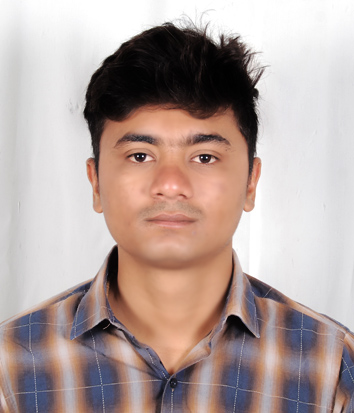

My name is Rushikesh Shivajirao Ware. I’m a Mechanical Engineering grad from Savitribai Phule Pune University, where I geeked out over numbers and designs, finishing with a pretty proud 8.66 CGPA. Now, I’m diving deep into the world of Data Analytics at George Mason University, aiming to blend my engineering smarts with the power of data.

My journey’s taken me from the structured world of engineering to the dynamic landscape of IT consulting, where I’ve tackled challenges in banking with Cognizant Technology Solutions. I’ve got a knack for making sense of data, using tools like Google Cloud Platform and machine learning to find solutions that matter. I’m all about learning and growing, which is why I’ve bagged certifications like Google Cloud Certified - Associate Cloud Engineer and dabbled in Python, and SQL.

But it’s not all work and no play. I’m passionate about giving back, teaching coding to the next generation, and being active in student associations. And when I’m off the clock, you’ll find me cheering for my favorite football/soccer teams or getting lost in the latest anime series. These hobbies aren’t just downtime; they teach me about teamwork, strategy, and the art of storytelling.

**Contact details:**

**Linkdin :** www.linkedin.com/in/rushikesh-ware10

**Email :** rushikeshsware@gmail.com